# Análisis Exploratorio del Dataset de Pingüinos

Glenda Blanc

2025-11-06

# 1 Contexto del dataset

El análisis presentado se basa en el conjunto de datos palmerpenguins, una alternativa popular y moderna al clásico iris. Este dataset recolectado por la Dra. Kristen Gorman y el equipo de la Estación Palmer, Antártida, abarca mediciones biométricas para 344 pingüinos de tres especies diferentes: Adelie, Chinstrap y Gentoo, observados en las islas Biscoe, Dream y Torgersen. Las variables clave incluyen mediciones corporales como la longitud y profundidad del pico (bill length and depth), la longitud de la aleta (flipper length), la masa corporal (body mass), y el sexo, proporcionando una base rica y balanceada para el análisis de clasificación multivariante y la regresión en un contexto ecológico. Su relevancia reside en la claridad de las distinciones entre especies, lo que lo convierte en un ejemplo canónico para demostrar la separabilidad lineal de las clases y la aplicación de modelos estadísticos predictivos.

# 2 Introducción

Este informe explora el dataset penguins, el cual contiene información morfológica de pingüinos de tres especies que habitan distintas islas en la región Antártica. A partir de una limpieza y transformación inicial, se realizará un análisis gráfico y exploratorio, incluyendo visualizaciones en 3D para facilitar la identificación de patrones multivariados.

**Esta es la primera oración: Negrilla, Roja y Fuente Grande.**

*Esta es la segunda oración: Cursiva, Azul y Fuente Mediana.*

Esta es la tercera oración: Normal, Verde y Fuente Pequeña.

# 3 Preparación de los datos

Primeras filas del dataset Pinguinos

| especie | isla | longitud_pico_mm | profundidad_pico_mm | longitud_aleta_mm | masa_corporal_g | sexo | anio |
| --- | --- | --- | --- | --- | --- | --- | --- |
| Adelie | Torgersen | 39.1 | 18.7 | 181 | 3750 | male | 2007 |
| Adelie | Torgersen | 39.5 | 17.4 | 186 | 3800 | female | 2007 |
| Adelie | Torgersen | 40.3 | 18.0 | 195 | 3250 | female | 2007 |
| Adelie | Torgersen | 36.7 | 19.3 | 193 | 3450 | female | 2007 |
| Adelie | Torgersen | 39.3 | 20.6 | 190 | 3650 | male | 2007 |
| Adelie | Torgersen | 38.9 | 17.8 | 181 | 3625 | female | 2007 |

# 4 Distribuciones por especie

## 4.1 Masa corporal

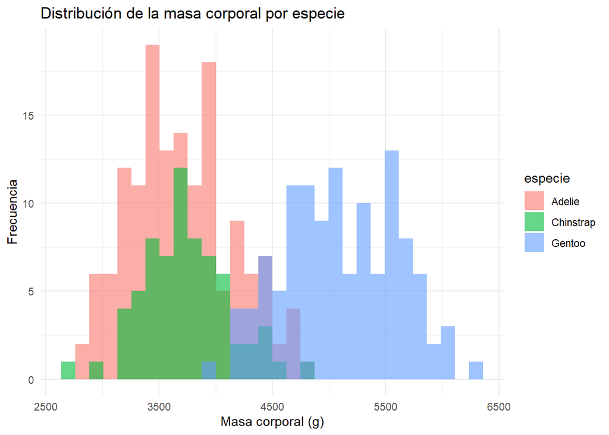

**Análisis:** Se observa que la especie Gentoo presenta masas corporales más elevadas, mientras que Adelie tiende a ser más ligera.

## 4.2 Relación entre longitud de pico y aleta

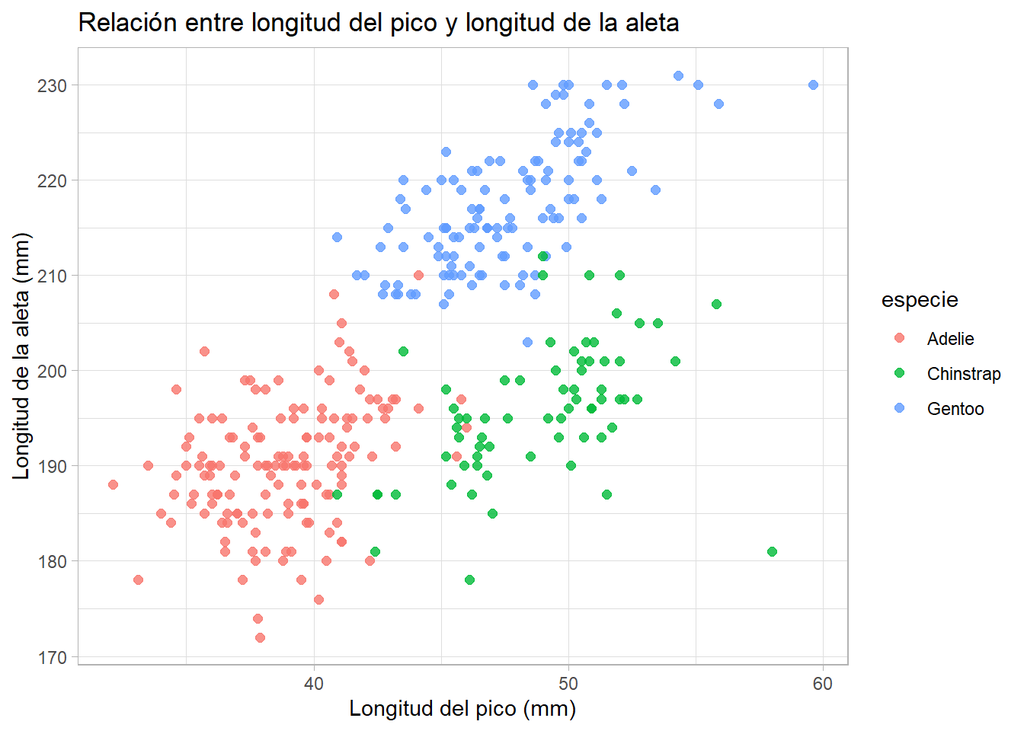

**Análisis:** Existe una correlación moderada entre ambas variables. Gentoo se distingue claramente por mayor tamaño corporal general.

# 5 Visualización 3D

Para observar mejor la distribución multivariada, se construye un gráfico 3D interactivo utilizando el paquete **plotly**

[interactive chart not shown]

**Análisis:** Esta visualización 3D permite distinguir claramente conglomerados por especie. Gentoo se agrupa en valores altos de las tres variables.

# 6 Comparación por sexo

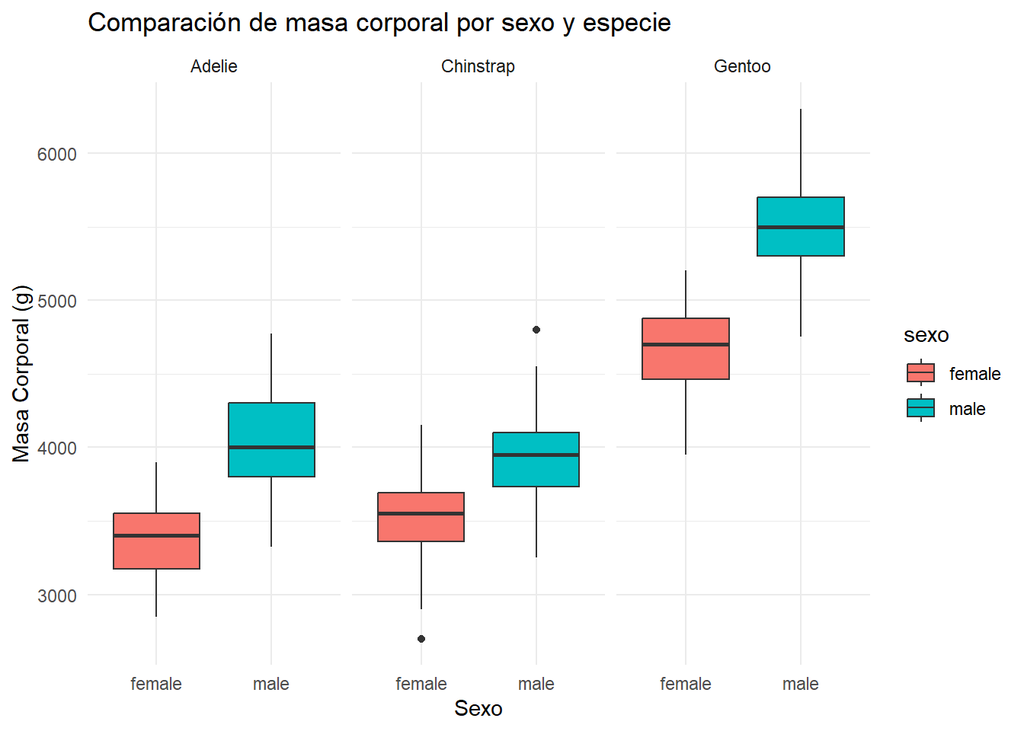

**Análisis:** En todas las especies, los machos tienden a tener una mayor masa corporal que las hembras, lo que sugiere un dimorfismo sexual morfológico.

# 7 Conclusiones

- Se evidencian diferencias marcadas entre especies en variables clave como - masa corporal y longitud de aleta.
- Gentoo presenta dimensiones corporales consistentemente más altas.
- El gráfico 3D permitió visualizar la estructura multivariada de forma clara.
- El dimorfismo sexual es evidente en todas las especies.
- Este análisis básico puede extenderse a modelos predictivos o dashboards interactivos.